# Tips for using Git and GitHub

Tom Palmer

01 November 2021

## Introduction

The following is intended as a set of tips for people learning how to use Git and GitHub.

There are many excellent guides to Git and GitHub online, e.g.,

- Intro to GitHub [here](https://guides.github.com/activities/hello-world/)
- GitHub Training & Guides YouTube channel [here](https://www.youtube.com/githubguides)
- Git documentation and training [here](https://git-scm.com/doc)
- Hadley Wickham on Git [here](https://r-pkgs.org/git.html)
- Jenny Bryan on Git and GitHub with R [here](https://happygitwithr.com/)

And most relevantly the OpenSAFELY documentation [here](https://docs.opensafely.org/getting-started/).

These tips are meant to supplement them.

## Tips

### Intro to Git

- Git was written to allow developers work on the source code of the Linux kernel
  - One kernel release they got in a terrible mess
  - This provoked Linus Torvalds into action
  - For an excellent insight into his thinking watch this talk he gave at Google [here](https://youtu.be/4XpnKHJAok8)
  - Git was designed to work with text files
  - (Especially if used at the command line) Git can be intimidating to use and we can get Git errors (which like LaTeX and R errors can be quite cryptic)

- A Git repository is a folder/directory on your computer which has been Git initialised
  - Using either the command line

    ```
    git init mynewfolder
    ```

  - Or GitHub Desktop

[figure not shown]

  - Repos on GitHub are already Git initialised
    - When you clone them down to your computer they work in GitHub Desktop
- Git is commonly referred to as version control software
- Git is better described as a *content addressable filesystem* which translates to *Git tracks the contents of the files in your repo*
  - Git takes snapshots of your files - when you tell it to - *commits*
  - Commits are identified by the SHA-1 hash of the contents of your files at that time

[figure not shown]

[figure not shown]

[figure not shown]

  - Git knows the state of your files at every commit
    - Can easily restore files to a previous state
  - For Git the state of your files only changes when their contents change
    - If you reopen a file, make no changes, then resave it, Git will show no changes
    - If you add an empty folder/directory to your repo Git will detect no changes in your repo
    - This differs to OneDrive/SharePoint/Google Drive which are file synchronisation systems
  - I recommend to not place your Git repos in a location that is sync’d by either OneDrive or Google Drive (they are very different syncing technologies to Git)

#### The `.git` folder

- When you initialise a directory the `.git` folder is created
- This contains all of the files Git uses to track the contents of your files
- Here is the `.git` folder of a repo on my computer (I have selected to View hidden files in Windows Explorer)

[figure not shown]

- Confusingly GitHub hides the `.git` folder from view

[figure not shown]

- Here are its contents - never edit these manually

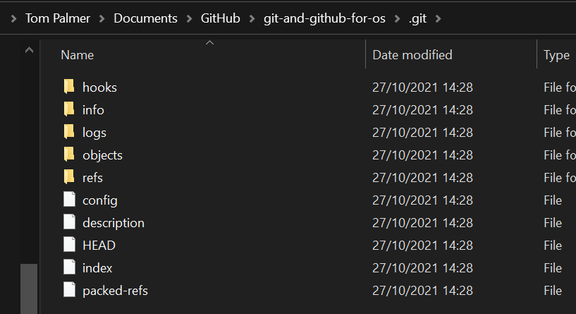

- Explanation of these is (from [here](https://www.tutorialspoint.com/what-is-git-folder-and-why-is-it-hidden))

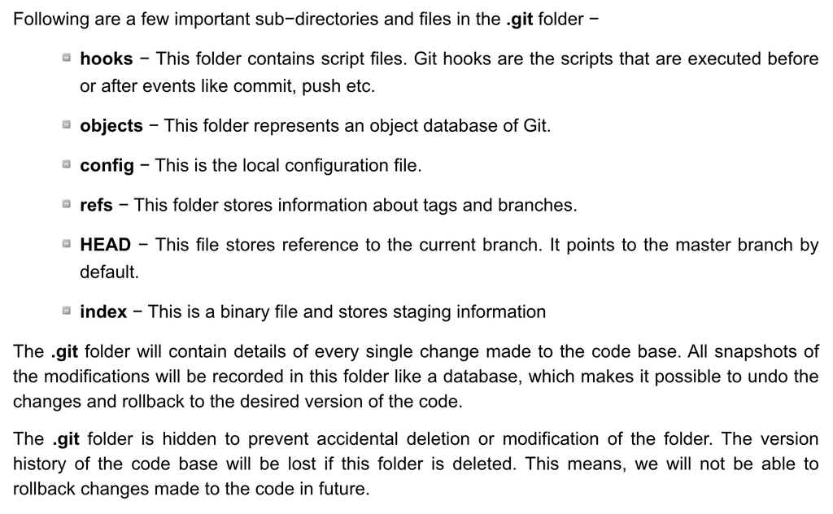

#### Common Git commands

- I recommend you use GitHub Desktop instead of these commands
- These commands are what GitHub Desktop is using behind the scenes
- Git is the name of the program, `git` is the name of the executable available at your command line

```
git init
git add <filename>
git status
git commit -m "Your commit message"
git commit --amend -m "Your amended commit message"
git push
git pull
git clone
git branch
git checkout
git merge
git fetch
```

### Installing Git

- Windows
  - Download and install from [here](https://git-scm.com/download/win)
- macOS comes with an out-dated version of Git
  - I recommend installing the Homebrew version
  - First install Homebrew, see instructions [here](https://brew.sh/)
  - Then run in your Terminal app

    ```
    brew upgrade
    brew install git
    ```

  - Additionally on a Mac it doesn’t hurt to install Xcode command line tools (i.e., avoid installing the whole of Xcode.)

    ```
    xcode-select --install
    ```

    - Must reinstall these everytime upgrade operating system versions, e.g., from Big Sur to Monterey
- Once Git is install its executable (called `git`) should be available at your command line
  - Check which version you have with (you want something recent-ish)

    ```
    git --version
    ```

  - On my Windows machine I have

    ```
    git version 2.33.1.windows.1
    ```

### Installing GitHub Desktop

- You could use Git through its command syntax however I recommend you use a graphical git editor
- For Windows and macOS download and install GitHub Desktop from [here](https://desktop.github.com/)
- A Linux version of GitHub Desktop available from [here](https://github.com/shiftkey/desktop/)

### Intro to GitHub

- GitHub is a Git web server, there are others e.g., [GitLab](https://about.gitlab.com/)
- Your repositories will be stored on GitHub, and you will clone them to your machine to work on them (or work on them in Gitpod)
- Under your user account you see the repos you are owner of
- On GitHub OpenSAFELY is an organization
  - The repos are owned by the organization so they show up under the organisation [here](https://github.com/opensafely)

[figure not shown]

#### GitHub PAT for R

- To create a GitHub Personal Access Token (PAT) to be allowed more downloads from GitHub per hour run in R

```r
install.packages("usethis")
library(usethis)
create_github_token()
```

#### GitHub CLI

- GitHub CLI stands for command line interface for operating GitHub
- Installation instructions are [here](https://github.com/cli/cli#readme)
- But I don’t recommend using this

### Git and GitHub Workflow

#### Standard GitHub workflow

- (I recommend to only fork a public repo if you intend to send a pull request to it)
- Fork the other person’s repo
- This creates a copy of their repo under your account (your fork)
- Clone your fork (the copy under your account) to your machine
- Create a new branch (do not work on `master`/`main`)
- Make your changes and commit them
- Push your new branch upto your GitHub (i.e., to your fork)
- Create a pull request (from your new branch) back to the default (`master`/`main`) branch of the original repo

#### Workflow with an OpenSAFELY GitHub repo

- Skip the forking step from the standard GitHub workflow
- Clone the repo to your local machine
  - Click: `Code` | `Open with GitHub Desktop`

[figure not shown]

  - Click `Clone` in the box which appears in GitHub Desktop

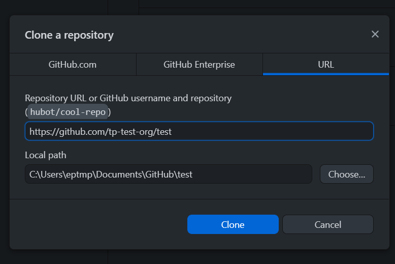

  - In GitHub Desktop (i.e. locally) make a new branch

[figure not shown]

- Do some work
  - Make some changes (to your `project.yaml`/`study_definition.py`/R scripts)
  - In GitHub Desktop select relevant changed lines and make small-ish commits with sensible commit messages
  - Do not commit changes to many files with a single commit message such as “Edits”!

[figure not shown]

- Push your new branch from your local machine upto GitHub
- Make a pull request from your branch to the default branch

### Making a pull request

- Amend/Edit pull request by modifying/adding commits on the branch from which you sent the PR
- Pull request reviews [here](https://docs.github.com/en/github/collaborating-with-pull-requests/reviewing-changes-in-pull-requests/about-pull-request-reviews)

### Common errors

#### Forgetting to pull down the latest changes from GitHub

- (Especially in the morning) It is very easy to forget to pull down latest changes when reopening a project
- Let’s say I or a colleague made changes and those are pushed to GitHub
  - The next day I restart work on a different computer, GitHub Desktop will show for example

[figure not shown]

- Fix
  - Move your changes to a new branch
  - Pull down the changes from GitHub
  - Merge your changes into the relevant branch

#### Merge conflict

See

- About merge conflicts [here](https://docs.github.com/en/github/collaborating-with-pull-requests/addressing-merge-conflicts/about-merge-conflicts)
- Resolving a merge conflict [here](https://docs.github.com/en/github/collaborating-with-pull-requests/addressing-merge-conflicts/resolving-a-merge-conflict-on-github)

### Additional topics

#### Writing good commit messages

- Follow the **standard** recommendations about making commit messages, see
  - [here](https://style.tidyverse.org/gitgithub.html) and
  - [here](https://chris.beams.io/posts/git-commit/)

#### Files for Git to ignore

- You should not commit all files in the folder on your computer into your repo
- The `.gitignore` file is a list of files and folders in your repo for Git to ignore
- Common files to ignore are
  - `.Rhistory`
  - `.DS_Store`

#### GitHub repos contain more than just code

- A repo for an R package will probably contain
  - The code for the R package
  - The code for its website (often made with pkgdown and hosted with GitHub Pages or Netlify)

[figure not shown]

  - Scripts for controlling continuous integration services such as GitHub Actions

### OpenSAFELY repos

- OpenSAFELY is a system of Python packages which run various Docker containers
  - The main GitHub organisation page is [here](https://github.com/opensafely)
  - All the core code is published in their opensafely-core organisation on GitHub [here](https://github.com/opensafely-core)
  - And there is also their opensafely-actions organisation [here](https://github.com/opensafely-actions)
- A Docker container is a like a virtual machine
  - It defines the operating system and programs running within it
  - On my Windows 10 machine I can run an Ubuntu docker container
  - Just because an R package is installed in the R installation on your machine does not mean that it is installed in the OpenSAFELY R Docker container

#### Getting started

- See OS page [here](https://docs.opensafely.org/getting-started/)
- If creating a new repo create from the OS template [here](https://github.com/opensafely/research-template)

[figure not shown]

- This is already Git initialized

#### Running jobs (on the dummy data)

- In your OS repo online
  - Use Gitpod
- On your own machine - install the following free software
  - (If on Windows - Windows Subsystem for Linux version 2)
  - Docker Desktop
  - Python
  - Git
  - GitHub Desktop
  - VSCode text editor